# MIMIC Project: Relative Hypoglycemia (Data Processing)

Wei-Hung Weng

November 4, 2016

# Summary

This code is to extract the variables from the whole MIMIC database. There are 50796 admissions and 42 variables in the final table `rh_1118.txt`.

# Patient Cohort

1. Patients with ICD code of `250.*`. Total 14222 admissions, with type 1 of 1700 admissions and type 2 of 12522 admissions. We used the end digit of ICD code to identify type 1 or type 2 diabetes.

```r
cohort1 <- dbGetQuery(con, "select hadm_id, subject_id, icd9_code from diagnoses_icd
                      where icd9_code like '250%' order by hadm_id")
cohort1$icd9_code <- as.numeric(cohort1$icd9_code)
cohort1$type_dm <- ifelse(cohort1$icd9_code %% 2 == 0, 2, 1)
cohort1$deleted <- 0
for (i in 1:(nrow(cohort1)-1)) {
  if (cohort1$hadm_id[i] == cohort1$hadm_id[i+1]) cohort1$deleted[i] <- 1
}
cohort1 <- subset(cohort1, cohort1$deleted == 0)[-5]
cohort1$criteria <- 1
nrow(cohort1)
```

```
## [1] 14222
```

```r
table(cohort1$type_dm)
```

```
##
##     1     2
##  1700 12522
```

```r
rm(i)
```

2. Patients with preceding glycated hemoglobin (HbA1c) > 7% before admission. There are three lab examination codes (50852, 50854, 51538) related to HbA1c blood test and we included them all. Total 1760 admissions fulfill this criteria. Then we combine two criteria and there are 14367 admissions fulfill the criteria.

```r
dbGetQuery(con, "SELECT * FROM d_labitems WHERE lower(label) LIKE '%a1c%'")
```

```
##   row_id itemid            label fluid  category loinc_code
## 1     53  50852 % HEMOGLOBIN A1C BLOOD CHEMISTRY     4548-4
## 2     55  50854     ABSOLUTE A1C BLOOD CHEMISTRY     4548-4
## 3    738  51538            [A1c] BLOOD CHEMISTRY     4548-4
```

```r
a1c <- dbGetQuery(con, "SELECT hadm_id, subject_id,
                  to_char(charttime, 'YYYY-MM-DD HH24:MI:SS') as time, valuenum
                  FROM labevents
                  WHERE (itemid = '50852' OR itemid = '51538' OR itemid = '50854') AND valuenum > 7
                  ORDER BY hadm_id, subject_id, charttime")
icustay <- dbGetQuery(con, "select hadm_id, subject_id,
                      to_char(intime, 'YYYY-MM-DD HH24:MI:SS') as time from icustays")
icustay$valuenum <- NA
cohort2 <- rbind(a1c, icustay)
rm(a1c, icustay)
cohort2 <- sqldf("select * from cohort2 order by subject_id, time", drv="SQLite") # sort by patient and time

# preserve the row (and the next row) which has a1c value (tag of a1c measurement)
# + no value in the next row (tag of ICU admission) + (id == the id in the next row)
cohort2$delete <- 1
for (i in 1:nrow(cohort2)) {
  if (cohort2$subject_id[i] == cohort2$subject_id[i+1] & !is.na(cohort2$valuenum[i]) & is.na(cohort2$valuenum[i+1]) ) {
    cohort2$delete[i] <- 0
    cohort2$delete[i+1] <- 0
  }
}
cohort2 <- subset(cohort2, cohort2$delete == 0)

cohort2 <- data.frame(hadm_id = unique(na.omit(cohort2$hadm_id)),
                      subject_id = 0, icd9_code = 0, type_dm = 0, criteria=2)
rm(i)
```

3. Patients with oral hypoglycemic agent (OHA) in their discharge summary. The OHA list is provided by John.

```r
oha_list <- read.table("OHA_flat.txt", stringsAsFactors=FALSE)$V1
ds <- dbGetQuery(con, "select * from noteevents where category like '%Discharge summary%'")
ds$text <- gsub("\t", " ", ds$text)
#ds$text <- gsub("\n", " ", ds$text)
ds$text <- gsub("\r", " ", ds$text)
ds <- ds[, c(3, 4, 11)]

# split notes by admissions, unique: 41103 patients, 52691 admissions
ds <- split(ds, ds$hadm_id)

dischargeSummary <- data.frame(hadm_id=numeric(), diabetesHist=numeric(),
                               diabetesMedAdmit=numeric(), diabetesMedDischarge=numeric())

for (j in 1:length(ds)) {
  txt <- ds[[j]]
  txt <- txt[which.min(txt$chartdate), ]
  sent <- strsplit(tolower(txt$text), "\n")

  # reset for each admission
  hadm_id <- txt$hadm_id
  section <- ""
  newSection <- ""
  admitFound <- 0
  dischargeFound <- 0
  histFound <- 0
  diabetesHist <- 0
  diabetesMedAdmit <- 0
  diabetesMedDischarge <- 0

  for (i in 1:length(sent[[1]])) {
    s <- sent[[1]][i]

      # locate the section
      if (grepl('med(ical)?\\s+hist(ory)?', s)) {
      newSection <- "hist"
      histFound <- 1
    } else if (grepl('medication|meds', s) & grepl('disch(arge)?', s)) {
      newSection <- "discharge"
      dischargeFound <- 1
    } else if (grepl('admission|admitting|home|nh|nmeds|pre(\\-|\\s)?(hosp|op)|current|previous|outpatient|outpt|outside|^[^a-zA-Z]*med(ication)?(s)?', s) & grepl('medication|meds|med', s)) {
      newSection <- "admit"
      admitFound <- 1
    }

    if (section != newSection) section <- newSection

    # identify diabetes/medication
    if ("hist" %in% section) {
      if (grepl("diabetes|diabetic", s)) diabetesHist <- 1
    } else if ("admit" %in% section) {
      if (mean(tolower(oha_list) %in% strsplit(s, " ")[[1]]) != 0) diabetesMedAdmit <- 1
      if (grepl('diab.*\\s+med(ication)?(s)?', s)) diabetesMedAdmit <- 1
    } else if ("discharge" %in% section) {
      if (mean(tolower(oha_list) %in% strsplit(s, " ")[[1]]) != 0) diabetesMedDischarge <- 1
      if (grepl('diab.*\\s+med(ication)?(s)?', s)) diabetesMedDischarge <- 1
    }

  }

  tmp <- data.frame(hadm_id=hadm_id, diabetesHist=diabetesHist,
                    diabetesMedAdmit=diabetesMedAdmit, diabetesMedDischarge=diabetesMedDischarge)
  dischargeSummary <- rbind(dischargeSummary, tmp)
}

write.table(dischargeSummary, "cohort_dischargeSummary.txt", sep="\t", quote=FALSE, row.names=FALSE)
```

```r
dischargeSummary <- read.table("cohort_dischargeSummary.txt", sep="\t", header=TRUE, stringsAsFactors=FALSE)

cohort3 <- dischargeSummary[dischargeSummary$diabetesHist==1, c("hadm_id")]
cohort4 <- dischargeSummary[dischargeSummary$diabetesMedAdmit==1, c("hadm_id")]

cohort3 <- data.frame(hadm_id=cohort3, subject_id=0, icd9_code=0, type_dm=0, criteria=3)
cohort4 <- data.frame(hadm_id=cohort4, subject_id=0, icd9_code=0, type_dm=0, criteria=4)

rm(ds, oha_list, dischargeSummary, diabetesMedAdmit, diabetesMedDischarge, diabetesHist,
   dischargeFound, dischargeSummary, admitFound, histFound, section, newSection, sent, s)
```

4. All the admissions identified above are collected and tagged as diabetic patients. There are 18767 admissions with diabetes, either by ICD code, preceding HbA1c, or the diagnosis of diabetes or diabetic medication in the discharge summaries.

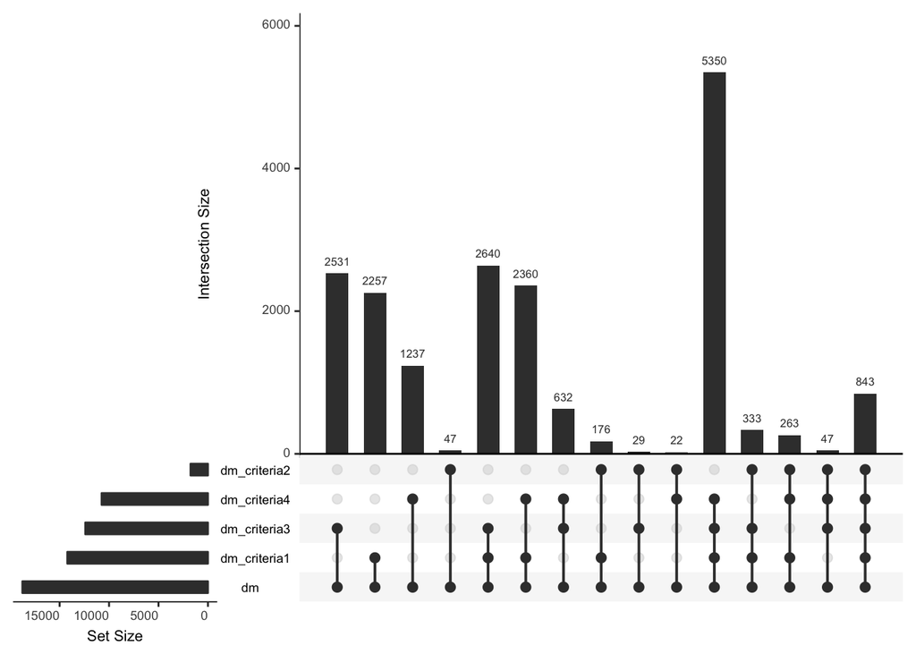

```r
cohort <- merge(cohort1, cohort2, by.x="hadm_id", by.y="hadm_id", all=T)
cohort <- cohort[, c(1, 4, 5, 9)] # hadm_id, type_dm, criteria only
colnames(cohort) <- c("hadm_id", "type_dm", "dm_criteria1", "dm_criteria2")
cohort <- merge(cohort, cohort3, by.x="hadm_id", by.y="hadm_id", all=T)
cohort <- cohort[, c(1:4, 8)]
colnames(cohort) <- c("hadm_id", "type_dm", "dm_criteria1", "dm_criteria2", "dm_criteria3")
cohort <- merge(cohort, cohort4, by.x="hadm_id", by.y="hadm_id", all=T)
cohort <- cohort[, c(1:5, 9)]
colnames(cohort) <- c("hadm_id", "type_dm", "dm_criteria1", "dm_criteria2", "dm_criteria3", "dm_criteria4")
cohort$dm <- 1 # dm (y/n)
cohort$dm_criteria1 <- ifelse(is.na(cohort$dm_criteria1), 0, 1)
cohort$dm_criteria2 <- ifelse(is.na(cohort$dm_criteria2), 0, 1)
cohort$dm_criteria3 <- ifelse(is.na(cohort$dm_criteria3), 0, 1)
cohort$dm_criteria4 <- ifelse(is.na(cohort$dm_criteria4), 0, 1)
cohort$type_dm <-ifelse(is.na(cohort$type_dm), 4, cohort$type_dm) # 4: is diabetes, but unknown type
write.table(cohort, "rh_dm_1118.txt", sep="\t", quote=FALSE, row.names=FALSE)
rm(cohort1, cohort2, cohort3, cohort4)
#upset(cohort, order.by="freq")
upset(cohort)
```

# Extract the general information

The main table includes the ID, age, gender, hospital admission and discharge time, hospital length of stay and survival day. Then we adjusted the abnormal age value to 91.4. Next, we created the binary values regarding 28-day, 90-day and 1-year mortality, and extracted the pre-ICU admission HbA1c value (5430 admissions) if there is any HbA1c record within 21 days before ICU admission. There are total 58976 admissions in the main table.

```r
main <- dbGetQuery(con, "select admissions.hadm_id, admissions.subject_id,
                   DATE_PART('year', admissions.admittime) - DATE_PART('year', patients.dob) as age,
                   patients.gender,
                   to_char(admissions.admittime, 'YYYY-MM-DD HH24:MI:SS') as admit_time,
                   to_char(admissions.dischtime, 'YYYY-MM-DD HH24:MI:SS') as disch_time,
                   DATE_PART('day', patients.dod - admissions.admittime) as survival_day,
                   (DATE_PART('day', admissions.dischtime - admissions.admittime) * 24 + DATE_PART('hour', admissions.dischtime - admissions.admittime))/24 as hosp_los
                   from mimiciii.admissions
                   inner join mimiciii.patients on admissions.subject_id = patients.subject_id")

# assign age > 200 to 91.4 (Leo: median age of patients age > 90, from MIMIC website)
for (i in 1:nrow(main)) {
  if(main$age[i] > 200) main$age[i] <- 91.4
}

main$mort28 <- ifelse(main$survival_day <= 28, 1, 0)
main$mort28[which(is.na(main$mort28))] <- 0
main$mort90 <- ifelse(main$survival_day <= 90, 1, 0)
main$mort90[which(is.na(main$mort90))] <- 0
main$mort365 <- ifelse(main$survival_day <= 365, 1, 0)
main$mort365[which(is.na(main$mort365))] <- 0

# for each admission, get the first ICU stay ID (use distinct on to the the first row) (57786)
icu_first <- dbGetQuery(con, "select distinct on (hadm_id) hadm_id, icustay_id,
                        to_char(intime, 'YYYY-MM-DD HH24:MI:SS') as icu_intime,
                        to_char(outtime, 'YYYY-MM-DD HH24:MI:SS') as icu_outtime,
                        los as icu_los
                        from mimiciii.icustays order by hadm_id, icu_intime")

main <- merge(main, icu_first, by.x="hadm_id", by.y="hadm_id", all=T) # 58976
rm(icu_first)

main <- merge(main, cohort, by.x="hadm_id", by.y="hadm_id", all=T)
rm(cohort)

main$dm[which(is.na(main$dm))] <- 0

# a1c prior to icu admission (see line 60, almost same but value no limitation)
lab_a1c <- dbGetQuery(con, "SELECT hadm_id, subject_id,
                      to_char(charttime, 'YYYY-MM-DD HH24:MI:SS') as time, valuenum
                      FROM mimiciii.labevents
                      WHERE (itemid = '50852' OR itemid = '51538' OR itemid = '50854')
                      ORDER BY hadm_id, subject_id, charttime")
icustay <- dbGetQuery(con, "select hadm_id, subject_id,
                      to_char(intime, 'YYYY-MM-DD HH24:MI:SS') as time from mimiciii.icustays")
icustay$valuenum <- NA # for combining with a1c value
a1c_prev_icu <- rbind(lab_a1c, icustay)
rm(lab_a1c, icustay)
# sort by patient and time
a1c_prev_icu <- sqldf("select * from a1c_prev_icu order by subject_id, time", drv="SQLite")

# preserve the row (and the next row) which has a1c value (tag of a1c measurement)
# + no value in the next row (tag of ICU admission) + (id == the id in the next row)
a1c_prev_icu$delete <- 1
for (i in 1:nrow(a1c_prev_icu)) {
  if (a1c_prev_icu$subject_id[i] == a1c_prev_icu$subject_id[i+1] & !is.na(a1c_prev_icu$valuenum[i]) & is.na(a1c_prev_icu$valuenum[i+1]) ) {
    a1c_prev_icu$delete[i] <- 0
    a1c_prev_icu$delete[i+1] <- 0
  }
}
a1c_prev_icu <- subset(a1c_prev_icu, a1c_prev_icu$delete == 0)

# a1c_prev_icu merge into main table
for (i in 1:(nrow(a1c_prev_icu)/2)) {
  if (difftime(a1c_prev_icu$time[i*2], a1c_prev_icu$time[i*2-1], units="days") < 21) {
    # only if prev a1c < 21 days
    a1c_prev_icu$valuenum[i*2] <- a1c_prev_icu$valuenum[i*2-1]
  }
}
a1c_prev_icu <- sqldf("select * from a1c_prev_icu order by hadm_id", drv="SQLite")
a1c_prev_icu <- na.omit(a1c_prev_icu)

# leave the first record (the value before ICU admission)
a1c_prev_icu$delete <- 0
for (i in 2:nrow(a1c_prev_icu)) {
  if (a1c_prev_icu$hadm_id[i] == a1c_prev_icu$hadm_id[i-1] ) {a1c_prev_icu$delete[i] <- 1}
}
a1c_prev_icu <- subset(a1c_prev_icu, a1c_prev_icu$delete == 0)[, c(1, 4)] # 5430 a1c records
colnames(a1c_prev_icu) <- c("hadm_id", "a1c_pre_icu")

# merge
main <- merge(main, a1c_prev_icu, by.x="hadm_id", by.y="hadm_id", all=T)
rm(a1c_prev_icu)


# elixhauser
elix <- read.csv("mimic3_elixhauser.csv", stringsAsFactors=F)[, 2:4]
main <- merge(main, elix, by.x="hadm_id", by.y="hadm_id", all=T)
rm(elix)


# sofa on admission
sofa <- read.csv("mimic3_sofa.csv", stringsAsFactors=F)
sofa_g <- sqldf("select icustay_id, min(icustay_day), sofa_total as sofa_1 from sofa group by icustay_id", drv="SQLite")
sofa_g$`min(icustay_day)` <- NULL
main <- merge(main, sofa_g, by.x="icustay_id", by.y="ICUSTAY_ID", all.x=T)
rm(sofa, sofa_g)


# rearranging the columns
main <- main[c("icustay_id", "hadm_id", "subject_id", "age", "gender",
             "dm", "type_dm", "a1c_pre_icu", "sofa_1", "elixhauser_hospital", "elixhauser_28day",
             "survival_day", "icu_los", "hosp_los", "mort28", "mort90",
             "mort365", "admit_time", "disch_time", "icu_intime", "icu_outtime")]
write.table(main, "rh_main_1118.txt", sep="\t", quote=FALSE, row.names=FALSE)

# other tables
# service <- dbGetQuery(con, "select distinct hadm_id, curr_service from services")
# dx <- dbGetQuery(con, "select admissions.hadm_id, admissions.subject_id, diagnoses_icd.icd9_code
#                  from admissions inner join diagnoses_icd on admissions.hadm_id = diagnoses_icd.hadm_id")
rm(i)
```

# Lactate

```r
dbGetQuery(con, "SELECT * FROM d_labitems WHERE lower(label) LIKE '%lact%'") # 50813 lactate
```

```
##   row_id itemid                          label                     fluid
## 1     14  50813                        LACTATE                     BLOOD
## 2     44  50843 LACTATE DEHYDROGENASE, ASCITES                   ASCITES
## 3    155  50954     LACTATE DEHYDROGENASE (LD)                     BLOOD
## 4    160  50959                MACRO PROLACTIN                     BLOOD
## 5    174  50973                      PROLACTIN                     BLOOD
## 6    215  51015     LACTATE DEHYDROGENASE, CSF CEREBROSPINAL FLUID (CSF)
## 7    254  51054 LACTATE DEHYDROGENASE, PLEURAL                   PLEURAL
##    category loinc_code
## 1 BLOOD GAS    32693-4
## 2 CHEMISTRY     2531-2
## 3 CHEMISTRY     2532-0
## 4 CHEMISTRY
## 5 CHEMISTRY     2842-3
## 6 CHEMISTRY     2528-8
## 7 CHEMISTRY     2530-4
```

```r
lac <- dbGetQuery(con, "SELECT hadm_id,
                  to_char(charttime, 'YYYY-MM-DD HH24:MI:SS') as charttime, valuenum
                  FROM labevents
                  WHERE hadm_id IS NOT NULL AND itemid = '50813'
                  ORDER BY hadm_id, charttime")
lac$charttime <- as.POSIXct(lac$charttime, format="%Y-%m-%d %H:%M:%S")
write.table(lac, "rh_lac_1118.txt", sep="\t", quote=FALSE, row.names=FALSE)

lac_pool <- dbGetQuery(con, "SELECT hadm_id, avg(valuenum) as lac_mean, max(valuenum) as lac_max, min(valuenum) as lac_min, stddev(valuenum) as lac_sd
                       FROM labevents
                       WHERE hadm_id IS NOT NULL AND itemid = '50813'
                       GROUP BY hadm_id ORDER BY hadm_id")

main <- merge(main, lac_pool, by.x="hadm_id", by.y="hadm_id", all=T)
rm(lac_pool)
```

# Glucose

```r
dbGetQuery(con, "SELECT * FROM d_labitems WHERE lower(label) LIKE '%gluc%'") # 50809 abg, 50931 chem
```

```
##   row_id itemid                label                     fluid   category
## 1    284  51084       GLUCOSE, URINE                     URINE  CHEMISTRY
## 2     10  50809              GLUCOSE                     BLOOD  BLOOD GAS
## 3     43  50842     GLUCOSE, ASCITES                   ASCITES  CHEMISTRY
## 4    132  50931              GLUCOSE                     BLOOD  CHEMISTRY
## 5    214  51014         GLUCOSE, CSF CEREBROSPINAL FLUID (CSF)  CHEMISTRY
## 6    222  51022 GLUCOSE, JOINT FLUID               JOINT FLUID  CHEMISTRY
## 7    234  51034  GLUCOSE, BODY FLUID          OTHER BODY FLUID  CHEMISTRY
## 8    253  51053     GLUCOSE, PLEURAL                   PLEURAL  CHEMISTRY
## 9    678  51478              GLUCOSE                     URINE HEMATOLOGY
##   loinc_code
## 1     2350-7
## 2     2339-0
## 3     2347-3
## 4     2345-7
## 5     2342-4
## 6     2348-1
## 7     2344-0
## 8     2346-5
## 9     5792-7
```

```r
gluc <- dbGetQuery(con, "SELECT hadm_id,
                  to_char(charttime, 'YYYY-MM-DD HH24:MI:SS') as charttime, valuenum
                  FROM mimiciii.labevents
                  WHERE hadm_id IS NOT NULL AND (itemid = '50809' OR itemid = '50931')
                  ORDER BY hadm_id, charttime")
#gluc$charttime <- as.POSIXct(gluc$charttime, format="%Y-%m-%d %H:%M:%S")
gluc$charttime <- ymd_hms(as.character(gluc$charttime))
gluc$backwindow <- gluc$charttime - lubridate::hours(6)
gluc$testid <- seq_along(gluc$charttime)

#glu$hypoglycemia <- ifelse(glu$valuenum <= 70.2, 1, 0)
gluc$anyhypo <- ifelse(gluc$valuenum <= 60, 1, 0)
gluc$anyhyper <- ifelse(gluc$valuenum > 180, 1, 0)

# Jesse
gluc2 <- gluc %>% left_join(main, by=c("hadm_id"="hadm_id")) %>%  group_by(hadm_id)
gluc2 <- gluc2 %>% full_join(gluc2, by=c("hadm_id"="hadm_id")) %>% group_by(testid.x) %>%
  summarise(rhtests=sum(charttime.y >= backwindow.x & charttime.y <= charttime.x & valuenum.x/valuenum.y <= 0.7, na.rm=T)) %>%
  rename(testid=testid.x) %>% left_join(gluc) %>% mutate(rh=as.numeric(rhtests > 0))
gluc <- gluc2


ds <- subset(main, select=c("hadm_id","icu_intime","admit_time"))
dg <- merge(gluc, ds, by.x="hadm_id",by.y="hadm_id")
dg$time <- -as.numeric(lubridate::ymd_hms(dg$admit_time[]) - lubridate::ymd_hms(dg$charttime[]))

sum(dg$valuenum < 0, na.rm=T)
```

```
## [1] 1
```

```r
gluc <- subset(dg, valuenum >= 0)

glucby <- dg %>% group_by(hadm_id) %>%
  dplyr::summarise(n=n(), mgluc=median(valuenum), maxgluc=max(valuenum), mingluc=min(valuenum),
            meangluc=mean(valuenum), sdgluc=sd(valuenum), los=max(abs(time)),
            freq=n/abs(los), rh=sum(rh, na.rm=TRUE), proprh=rh/n,
            anyhypo=sum(valuenum < 60), anyhyper=sum(valuenum > 180))

glucby <- dg %>% group_by(hadm_id) %>% summarise(mintime=min(time)) %>%
  right_join(dg, by=c("hadm_id"="hadm_id")) %>% group_by(hadm_id) %>%
  filter(time==mintime) %>% ungroup() %>%
  select(hadm_id, mintime, first_charttime=charttime, firstgluc=valuenum) %>%
  # use mean since some adm has two glucose at the first day
  right_join(glucby, by=c("hadm_id"="hadm_id"))

write.table(gluc, "rh_gluc_1118.txt", sep="\t", quote=FALSE, row.names=FALSE)
main <- merge(main, glucby, by.x="hadm_id", by.y="hadm_id", all=T)

# # characteristics of glucose records
# for (i in 1:nrow(glu)) {
#
#   # if the next row is in the same admission then keep processing, otherwise skip
#   if (glu$hadm_id[i+1] == glu$hadm_id[i]) {
#
#     # calculate time difference (all comparing to the previous record, as following)
#     glu$time_diff[i+1] <- difftime(glu$charttime[i+1], glu$charttime[i], units="hours")
#
#     # calculate gluLac glucose value difference
#     glu$value_diff[i+1] <- glu$valuenum[i+1] - glu$valuenum[i]
#
#     # calculate value difference (in percantage) (compare to the previous value)
#     glu$drop_percentage[i+1] <- (glu$valuenum[i+1] - glu$valuenum[i]) / glu$valuenum[i]
#
#     }
# }
#
# # find RH and RRH
# glu$rh <- ifelse(glu$hypoglycemia == 0 & glu$drop_percentage <= -0.3 & glu$time_diff <= 6, 1, 0)
# glu$rrh <- ifelse(glu$hypoglycemia == 0 & glu$drop_percentage <= -0.3 & glu$time_diff <= 4, 1, 0)
#
# # find hypoglycemia after previous RH/RRH &
# # find hypoglycemia after hyperglycemia (> 10 mmol/L (>180 mg/dl))
# glu$hypo_after_rh <- 0
# glu$hypo_after_rrh <- 0
# glu$rh_after_hyper <- 0
#
# for (i in 2:nrow(glu)) {
#   if (glu$hadm_id[i] == glu$hadm_id[i-1] & glu$hypoglycemia[i] == 1 & glu$rh[i] == 1) {
#     glu$hypo_after_rh[i] = 1
#   }
#   if (glu$hadm_id[i] == glu$hadm_id[i-1] & glu$hypoglycemia[i] == 1 & glu$rrh[i] == 1) {
#     glu$hypo_after_rrh[i] = 1
#   }
#   if (glu$hadm_id[i] == glu$hadm_id[i-1] & glu$rh[i] == 1 & glu$valuenum[i-1] > 180) {
#     glu$rh_after_hyper[i] = 1
#   }
# }

# # aggregate and merge to main table
# glu_pool <- sqldf("SELECT hadm_id, avg(valuenum) as glu_mean, max(valuenum) as glu_max, min(valuenum) as glu_min,
#                    max(hypoglycemia=1) as hypoglycemia, sum(hypoglycemia=1) as hypoglycemia_freq, max(hyperglycemia=1) as hyperglycemia, sum(hyperglycemia=1) as hyperglycemia_freq,
#                    max(rh=1) as rh, sum(rh=1) as rh_freq, max(rrh=1) as rrh, sum(rrh=1) as rrh_freq,
#                    max(hypo_after_rh=1) as hypo_after_rh, max(hypo_after_rrh=1) as hypo_after_rrh, max(rh_after_hyper=1) as rh_after_hyper
#                    FROM glu
#                    WHERE hadm_id IS NOT NULL
#                    GROUP BY hadm_id ORDER BY hadm_id", drv='SQLite')
# main <- merge(main, glu_pool, by.x="hadm_id", by.y="hadm_id", all=T)
# rm(glu_pool)
```

# Finger stick

Total 684529 records with finger stick sugar value.

```r
id_fs <- dbGetQuery(con, "SELECT itemid, label, linksto FROM d_items WHERE lower(label) LIKE '%fing%'")
id_fs <- id_fs[, 1]
fs <- data.frame()
for (i in 1:length(id_fs)) {
  tmp <- dbGetQuery(con, paste0("select icustay_id, hadm_id, itemid, valuenum as fs_value,
to_char(charttime, 'YYYY-MM-DD HH24:MI:SS') as time from mimiciii.chartevents where itemid = ", id_fs[i]," "))
  fs <- rbind(fs, tmp)
}

write.table(fs, "rh_fingersugar_1118.txt", sep="\t", quote=FALSE, row.names=FALSE)
rm(id_fs)
```

# Insulin

Next, we identified the items related to insulin from three tables, chartevents, inputevents_cv and inputevents_mv. There are 1063114 records with insulin administration.

```r
id_ins <- dbGetQuery(con, "select itemid, label, linksto from mimiciii.d_items where lower(label) like '%insulin%'")
id_ins_chart <- id_ins[c(1:6, 21), 1]
id_ins_cv <- id_ins[7:14, 1]
id_ins_mv <- id_ins[15:20, 1]

ins <- data.frame()

for (i in 1:length(id_ins_chart)) {
  tmp <- dbGetQuery(con, paste0("select icustay_id, hadm_id, itemid, valuenum as amount, valueuom as amountuom, valuenum as rate, valueuom as rateuom,
                                to_char(charttime, 'YYYY-MM-DD HH24:MI:SS') as starttime,
                                to_char(charttime, 'YYYY-MM-DD HH24:MI:SS') as endtime,
                                itemid as route
                                from chartevents where itemid = ", id_ins_chart[i], " "))
  ins <- rbind(ins, tmp)
}
# can't find the route in chartevents
ins$route <- -1
rm(id_ins_chart)

for (i in 1:length(id_ins_cv)) {
  tmp <- dbGetQuery(con, paste0("select icustay_id, hadm_id, itemid, amount, amountuom, rate, rateuom,
                                to_char(charttime, 'YYYY-MM-DD HH24:MI:SS') as starttime,
                                to_char(charttime, 'YYYY-MM-DD HH24:MI:SS') as endtime,
                                originalroute as route
                                from inputevents_cv where itemid = ", id_ins_cv[i], " "))
  ins <- rbind(ins, tmp)
}
rm(id_ins_cv)

for (i in 1:length(id_ins_mv)) {
  tmp <- dbGetQuery(con, paste0("select icustay_id, hadm_id, itemid, amount, amountuom, rate, rateuom,
                                to_char(starttime, 'YYYY-MM-DD HH24:MI:SS') as starttime,
                                to_char(endtime, 'YYYY-MM-DD HH24:MI:SS') as endtime,
                                ordercategoryname as route
                                from inputevents_mv where itemid = ", id_ins_mv[i], " "))
  ins <- rbind(ins, tmp)
}
rm(id_ins_mv)

ins$route_iv <- ifelse(ins$route %in% c("01-Drips", "05-Med Bolus", "12-Parenteral Nutrition", "Drip",
                                  "Intravenous", "Intravenous Push", "IV Drip") |
                         ins$itemid %in% id_ins[c(3, 6, 8, 10:14, 16, 20, 21), 1], 1, 0)
ins$route_sc <- ifelse(ins$route %in% c("06-Insulin (Non IV)") |
                         ins$itemid %in% id_ins[c(1, 2, 4, 5, 7, 9, 15:20), 1], 1, 0)

rm(id_ins)

write.table(ins, "rh_insulin_1118.txt", sep="\t", quote=FALSE, row.names=FALSE)

# aggregate and merge to main table
ins_pool <-  sqldf("SELECT hadm_id, avg(amount) as ins_mean, max(route_iv) as ins_iv, max(route_sc) as ins_sc FROM ins
                   WHERE hadm_id IS NOT NULL
                   GROUP BY hadm_id ORDER BY hadm_id", drv='SQLite')
ins_pool$ins_mean[which(is.na(ins_pool$ins_mean))] <- -99 # -99 = unknown

main <- merge(main, ins_pool, by.x="hadm_id", by.y="hadm_id", all=T)
rm(ins_pool)
```

# TPN

589060 records with TPN.

```r
id_tpn <- dbGetQuery(con, "select itemid, label, linksto from d_items where lower(label) like '%tpn%'")
id_tpn_chart <- id_tpn[1:3, 1]
id_tpn_cv <- id_tpn[c(4:46, 49), 1]
id_tpn_mv <- id_tpn[c(47, 48), 1]
rm(id_tpn)

tpn <- data.frame()

for (i in 1:length(id_tpn_chart)) {
  tmp <- dbGetQuery(con, paste0("select icustay_id, hadm_id, itemid, valuenum as amount, valueuom as amountuom, valuenum as rate, valueuom as rateuom,
                                to_char(charttime, 'YYYY-MM-DD HH24:MI:SS') as starttime,
                                to_char(charttime, 'YYYY-MM-DD HH24:MI:SS') as endtime,
                                itemid as route
                                from chartevents where itemid = ", id_tpn_chart[i]," "))
  tpn <- rbind(tpn, tmp)
}
tpn$route <- -1
rm(id_tpn_chart)

for (i in 1:length(id_tpn_cv)) {
  tmp <- dbGetQuery(con, paste0("select icustay_id, hadm_id, itemid, amount, amountuom, rate, rateuom,
                                to_char(charttime, 'YYYY-MM-DD HH24:MI:SS') as starttime,
                                to_char(charttime, 'YYYY-MM-DD HH24:MI:SS') as endtime,
                                originalroute as route
                                from inputevents_cv where itemid = ", id_tpn_cv[i]," "))
  tpn <- rbind(tpn, tmp)
}
rm(id_tpn_cv)

for (i in 1:length(id_tpn_mv)) {
  tmp <- dbGetQuery(con, paste0("select icustay_id, hadm_id, itemid, amount, amountuom, rate, rateuom,
                                to_char(starttime, 'YYYY-MM-DD HH24:MI:SS') as starttime,
                                to_char(endtime, 'YYYY-MM-DD HH24:MI:SS') as endtime,
                                ordercategoryname as route
                                from inputevents_mv where itemid = ", id_tpn_mv[i]," "))
  tpn <- rbind(tpn, tmp)
}
rm(id_tpn_mv)

write.table(tpn, "rh_tpn_1118.txt", sep="\t", quote=FALSE, row.names=FALSE)

# aggregate and merge to main table
tpn_pool <- sqldf("SELECT hadm_id, max(amount) as tpn FROM tpn
                  WHERE hadm_id IS NOT NULL
                  GROUP BY hadm_id ORDER BY hadm_id", drv='SQLite')
tpn_pool$tpn[which(is.na(tpn_pool$tpn))] <- -99 # -99 = unknown

main <- merge(main, tpn_pool, by.x="hadm_id", by.y="hadm_id", all=T)
rm(tpn_pool)
```

# Vasopressor

171219 records with vasopressor.

```r
id_vasop <- dbGetQuery(con, "select itemid, label, linksto from d_items where lower(label) like '%vasop%'")
id_vasop_chart <- id_vasop[1:10, 1]
id_vasop_cv <- id_vasop[11:13, 1]
id_vasop_mv <- id_vasop[14, 1]
rm(id_vasop)

vasop <- data.frame()

for (i in 1:length(id_vasop_chart)) {
  tmp <- dbGetQuery(con, paste0("select icustay_id, hadm_id, itemid, valuenum as amount, valueuom as amountuom, valuenum as rate, valueuom as rateuom,
                                to_char(charttime, 'YYYY-MM-DD HH24:MI:SS') as starttime,
                                to_char(charttime, 'YYYY-MM-DD HH24:MI:SS') as endtime,
                                itemid as route
                                from chartevents where itemid = ", id_vasop_chart[i]," "))
  vasop <- rbind(vasop, tmp)
}
vasop$route <- -1
rm(id_vasop_chart)

for (i in 1:length(id_vasop_cv)) {
  # inputevents_cv NO endtime???
  tmp <- dbGetQuery(con, paste0("select icustay_id, hadm_id, itemid, amount, amountuom, rate, rateuom,
                                to_char(charttime, 'YYYY-MM-DD HH24:MI:SS') as starttime,
                                to_char(charttime, 'YYYY-MM-DD HH24:MI:SS') as endtime,
                                originalroute as route
                                from inputevents_cv where itemid = ", id_vasop_cv[i]," "))
  vasop <- rbind(vasop, tmp)
}
rm(id_vasop_cv)

for (i in 1:length(id_vasop_mv)) {
  tmp <- dbGetQuery(con, paste0("select icustay_id, hadm_id, itemid, amount, amountuom, rate, rateuom,
                                to_char(starttime, 'YYYY-MM-DD HH24:MI:SS') as starttime,
                                to_char(endtime, 'YYYY-MM-DD HH24:MI:SS') as endtime,
                                ordercategoryname as route
                                from inputevents_mv where itemid = ", id_vasop_mv[i]," "))
  vasop <- rbind(vasop, tmp)
}
rm(id_vasop_mv)

write.table(vasop, "rh_vasopressor_1118.txt", sep="\t", quote=FALSE, row.names=FALSE)

# aggregate and merge to main table
vasop_pool <- sqldf("SELECT hadm_id, max(amount) as vasop FROM vasop
                  WHERE hadm_id IS NOT NULL
                  GROUP BY hadm_id ORDER BY hadm_id", drv='SQLite')
vasop_pool$vasop[which(is.na(vasop_pool$vasop))] <- -99 # -99 = unknown

main <- merge(main, vasop_pool, by.x="hadm_id", by.y="hadm_id", all=T)
rm(vasop_pool)
```

# Ventilator

```r
id_ventilat <- dbGetQuery(con, "select itemid, label, linksto from d_items where lower(label) like '%ventilat%'")
id_ventilat_chart <- id_ventilat[c(1, 2, 3, 4, 5, 7, 10, 11, 14), 1]
id_ventilat_proc <- id_ventilat[c(12, 13), 1]
rm(id_ventilat)

ventilat <- data.frame()

for (i in 1:length(id_ventilat_chart)) {
  tmp <- dbGetQuery(con, paste0("select icustay_id, hadm_id,
                                to_char(charttime, 'YYYY-MM-DD HH24:MI:SS') as starttime,
                                to_char(charttime, 'YYYY-MM-DD HH24:MI:SS') as endtime
                                from chartevents where itemid = ", id_ventilat_chart[i]," "))
  ventilat <- rbind(ventilat, tmp)
}
rm(id_ventilat_chart)

for (i in 1:length(id_ventilat_proc)) {
  # inputevents_cv NO endtime???
  tmp <- dbGetQuery(con, paste0("select icustay_id, hadm_id,
                                to_char(starttime, 'YYYY-MM-DD HH24:MI:SS') as starttime,
                                to_char(endtime, 'YYYY-MM-DD HH24:MI:SS') as endtime
                                from procedureevents_mv where itemid = ", id_ventilat_proc[i]," "))
  ventilat <- rbind(ventilat, tmp)
}
rm(id_ventilat_proc)

write.table(ventilat, "rh_ventilator_1118.txt", sep="\t", quote=FALSE, row.names=FALSE)

# aggregate and merge to main table
ventilat_pool <- sqldf("SELECT hadm_id, icustay_id as ventilat FROM ventilat
                    WHERE hadm_id IS NOT NULL
                    GROUP BY hadm_id ORDER BY hadm_id", drv='SQLite')

main <- merge(main, ventilat_pool, by.x="hadm_id", by.y="hadm_id", all=T)
rm(ventilat_pool, tmp)
```

# Create binary output for insulin, TPN, vasopressor and ventilator

Finally, we created the binary variables for insulin, TPN, vasopressor and ventilator use, and removed the admissions with age less than 18. Our cohort includes 50796 hospital admissions, with 38578 individuals and 49726 ICU admissions.

```r
main$ins_mean <- ifelse(!is.na(main$ins_mean), 1, 0) # use insulin or ot
main$tpn <- ifelse(!is.na(main$tpn), 1, 0) # use tpn or not
main$vasop <- ifelse(!is.na(main$vasop), 1, 0) # use vasopressor or not
main$ventilat <- ifelse(!is.na(main$vent), 1, 0) # use ventilation or not

main <- main %>% group_by(hadm_id) %>% summarise(firstgluc=mean(firstgluc)) %>%
  right_join(main, by=c("hadm_id"="hadm_id"))
main$firstgluc.y <- NULL
colnames(main)[2] <- "firstgluc"
main <- main[!duplicated(main), ] # 58976 admissions

write.table(main, "rh_main_1118.txt", sep="\t", quote=FALSE, row.names=FALSE)

main18 <- main[main$age >= 18, ] # 50796 admissions
write.table(main18, "rh_1118.txt", sep="\t", quote=FALSE, row.names=FALSE)
```

# Database disconnection

```r
cons <- dbListConnections(MySQL())
for (con in cons) {dbDisconnect(con)}
cons <- dbListConnections(dbDriver("PostgreSQL"))
for (con in cons) {dbDisconnect(con)}
```